# INTRODUCTION TO GGPLOT2: THEMES

### 4.2 Theme flexibility

If you use too many plots within a presentation, you will want to have a consistency in the style. Once you settle with a specific theme, we can apply it to all plots of the same type. Creating a theme from scratch is a detailed process that we don’t want to repeat for every plot.

Draw the scatter plot and save it as an object `z`:

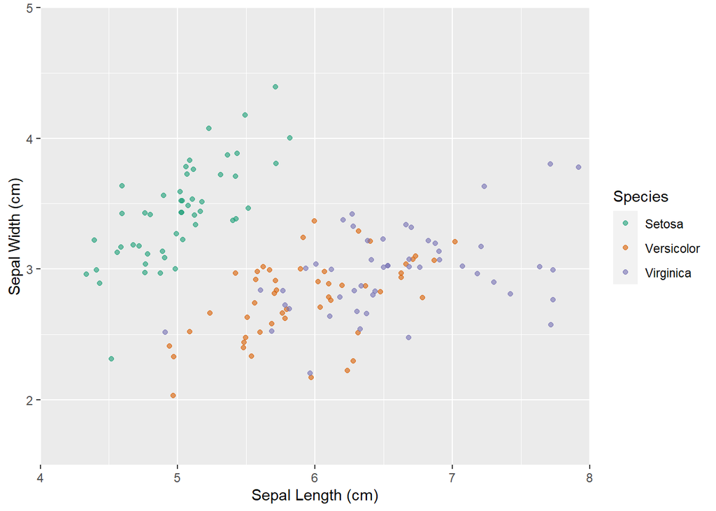

```r
z <- ggplot(iris, aes(Sepal.Length, Sepal.Width,
                      col = Species)) +
  geom_jitter(alpha = 0.6) +
  scale_x_continuous("Sepal Length (cm)",
                     limits = c(4, 8),
                     expand = c(0, 0)) +
  scale_y_continuous("Sepal Width (cm)",
                     limits = c(1.5, 5),
                     expand = c(0, 0)) +
  scale_color_brewer("Species",
                     palette = "Dark2",
                     labels = c("Setosa", "Versicolor", "Virginica"))
z
```

We can adjust specific theme arguments to get the desired plot style, like font family, size and the title color…

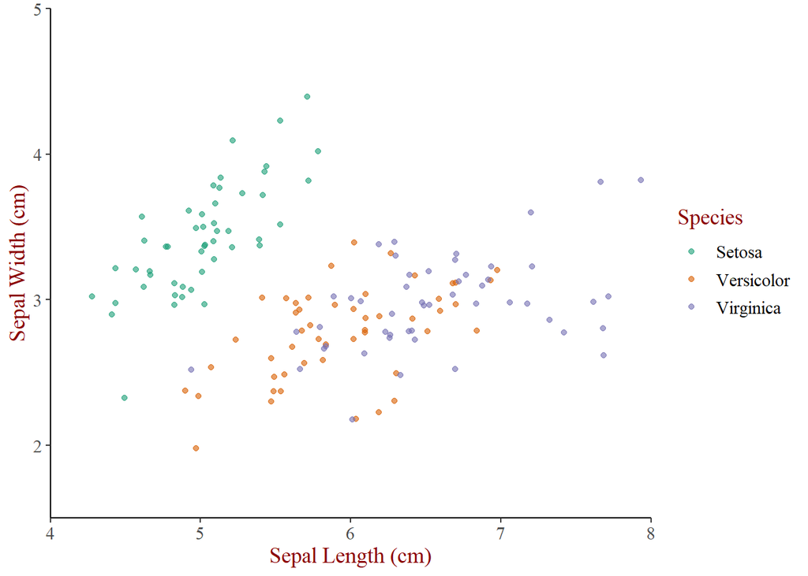

```r
z + theme(text = element_text(family = "serif",
                              size = 14),
          rect = element_blank(),
          panel.grid = element_blank(),
          title = element_text(color = "#8b0000"),
          axis.line = element_line(color = "black"))
```

The first method in automating this process is to save the theme layer. For example, apply this style to another plot:

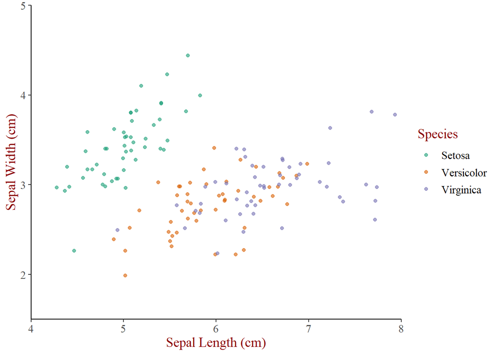

```r
theme_iris <- theme(text = element_text(family = "serif",
                                        size = 14),
                    rect = element_blank(),
                    panel.grid = element_blank(),
                    title = element_text(color = "#8b0000"),
                    axis.line = element_line(color = "black"))
z + theme_iris
```

The histogram now has the same style as the scatter plot, without having to retype the whole theme layer. Even when we want to modify some other specific elements of the plot, we can just add another theme layer which override the any previous setting.

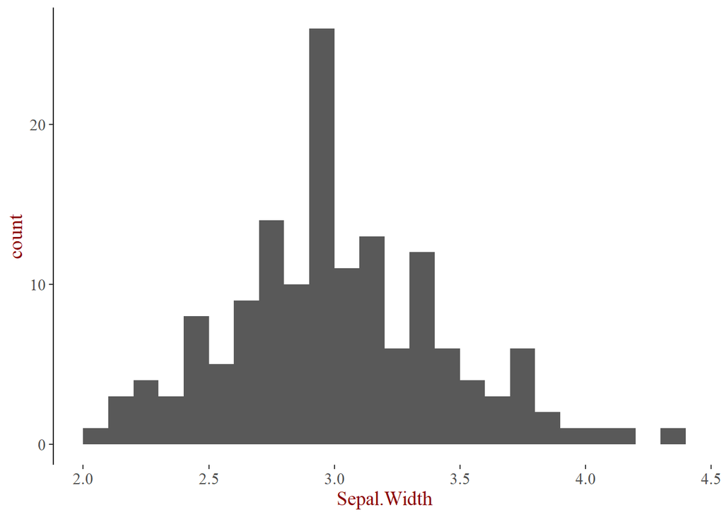

```r
ggplot(iris, aes(Sepal.Width)) +
  geom_histogram(binwidth = 0.1,
                 center = 0.05) +
  theme_iris +
  theme(axis.line.x = element_blank()) # remove the x axis.
```

### 4.3 Built-in themes

Defining theme as an object itself is pretty flexible way of working with theme, but we can also access the built-in theme templates. Built-in theme functions begin with `theme_*`.

- `theme_gray()`: default theme
- `theme_classic()`: great for publication-quality

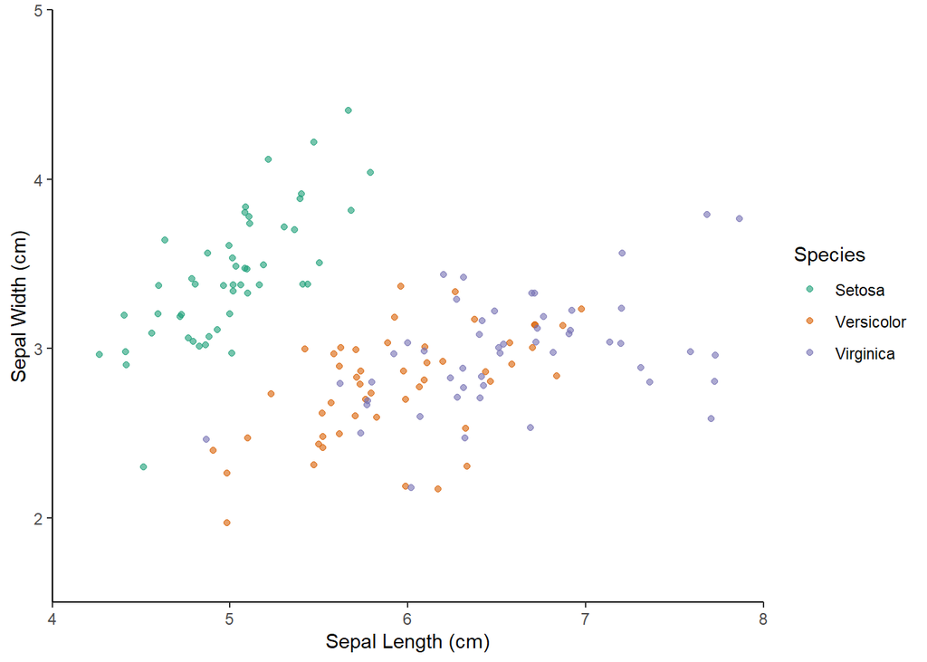

```r
z + theme_classic()
```

- `theme_bw()`: useful with transparency.

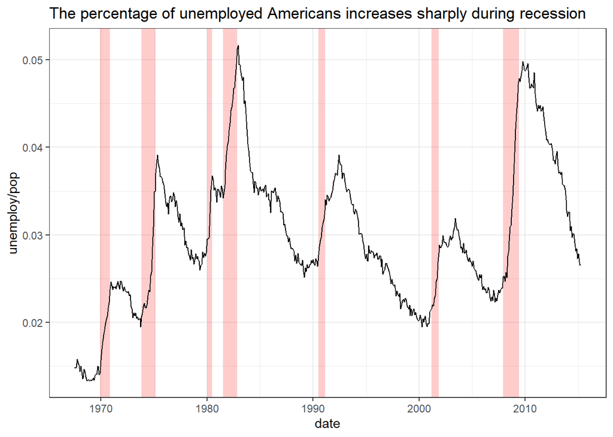

```r
plt_prop_unemployed_over_time + theme_bw()
```

- `theme_void()`: removes everything but the data

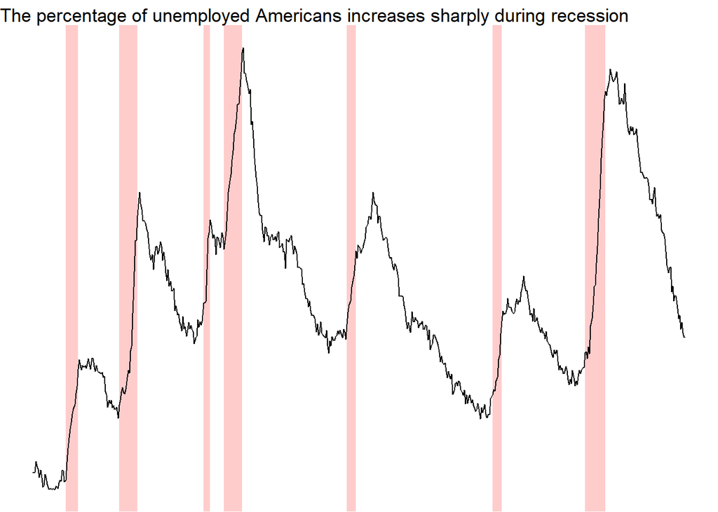

```r
plt_prop_unemployed_over_time + theme_void()
```

Outside of **ggplot2**, another source of pre-defined themes is the **ggthemes** package.

```r
library(ggthemes)
```

The *tufte* theme mimics Tufte’s classic style, which removes all non-data ink and sets the font to a *serif* typeface.

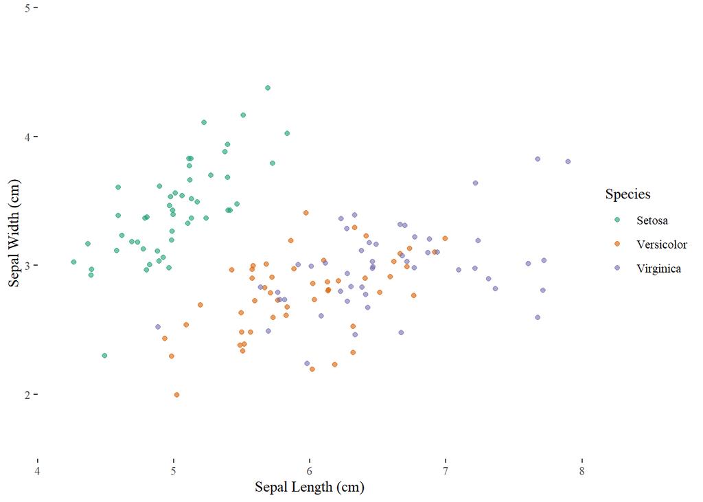

```r
z + theme_tufte()
```

Add the *fivethirtyeight.com* theme to the plot:

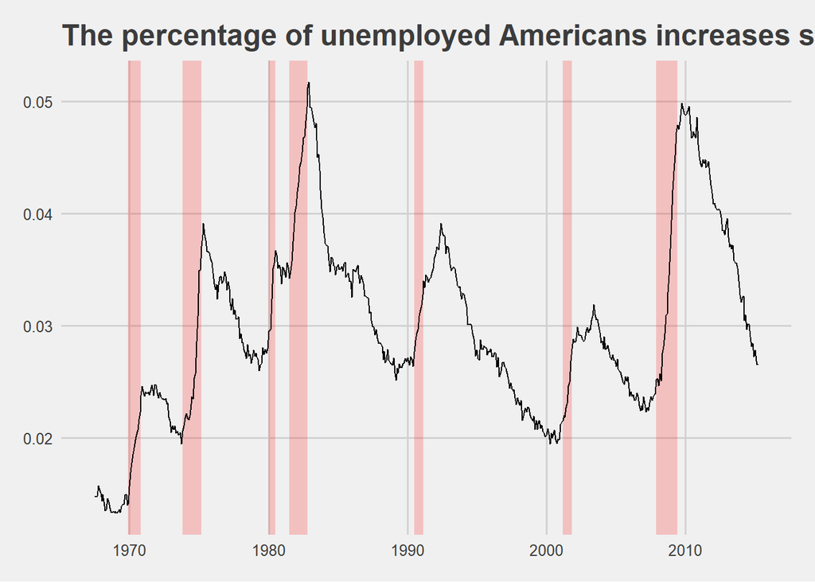

```r
plt_prop_unemployed_over_time + theme_fivethirtyeight()
```

Use the Wall Street Journal theme:

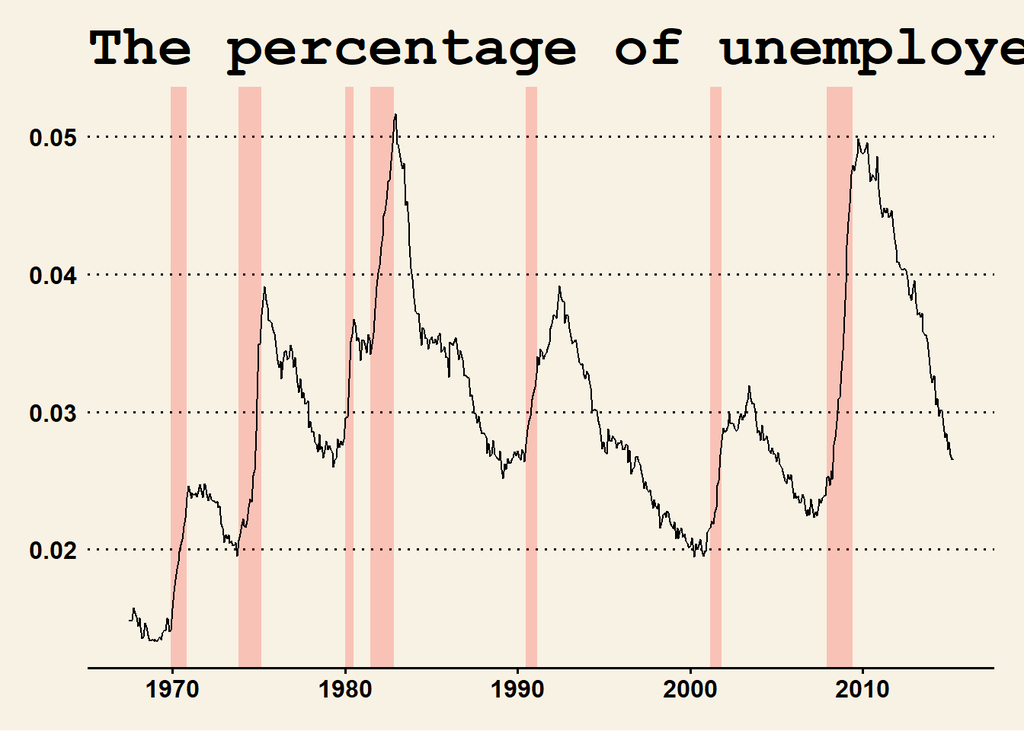

```r
plt_prop_unemployed_over_time + theme_wsj()
```

### 4.4 Updating themes

Reusing a theme across many plots helps to provide a consistent style. There are several options for this.

- Assign the theme to a variable, and add it to each plot. `theme_update()` commands updates the default theme and saves the current default.

```r
original <- theme_update(text = element_text(family = "serif",
                                             size = 14),
                         rect = element_blank(),
                         panel.grid = element_blank(),
                         title = element_text(color = "#8b0000"),
                         axis.line = element_line(color = "black"))
```

Now all plots have the same theme.

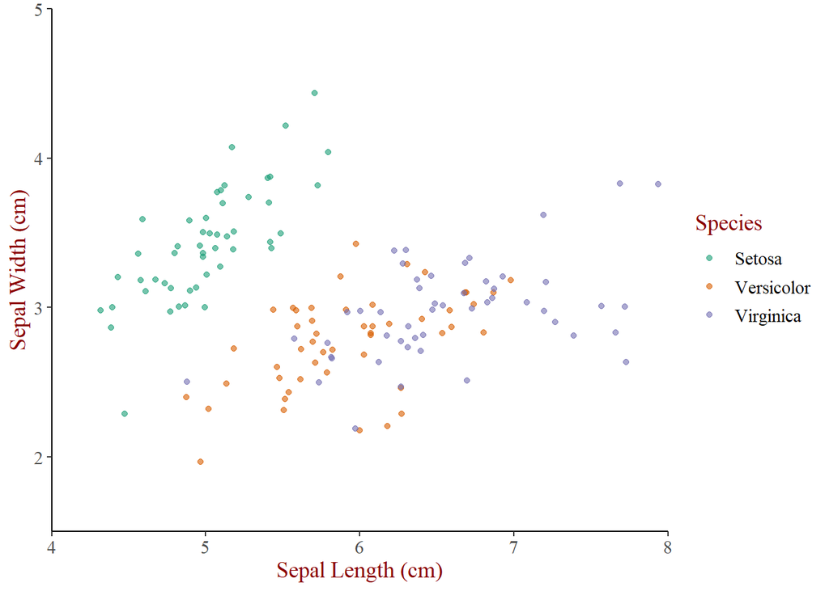

```r
z
```

We can set a complete theme object, like `original`, using the `theme_set()` function.

```r
theme_set(original)
```

Save the theme for the `economics` dataset as `theme_recession`:

```r
theme_recession <- theme(
  rect = element_rect(fill = "grey92"),
  legend.key = element_rect(color = NA),
  axis.ticks = element_blank(),
  panel.grid = element_blank(),
  panel.grid.major.y = element_line(color = "white",
                                    size = 0.5,
                                    linetype = "dotted"),
  axis.text = element_text(color = "grey25"),
  plot.title = element_text(face = "italic", size = 16),
  legend.position = c(0.6, 0.1)
)
```

Add the Tufte theme and `theme_recession` together:

```r
theme_tufte_recession <- theme_tufte() + theme_recession
```

Use the Tufte recession theme by adding it to the plot:

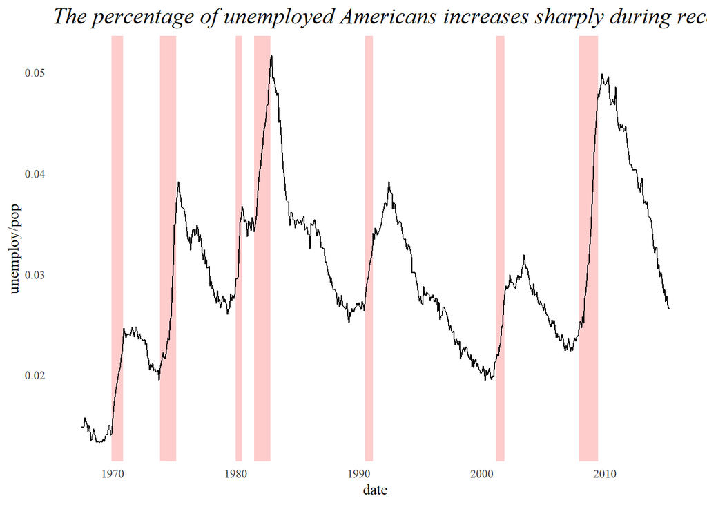

```r
plt_prop_unemployed_over_time + theme_tufte_recession
```

- `theme_set()`: set your theme as the default using, for example, set `theme_tufte_recession` as the default theme:

```r
theme_set(theme_tufte_recession)
```

Draw the plot (without explicitly adding a theme):

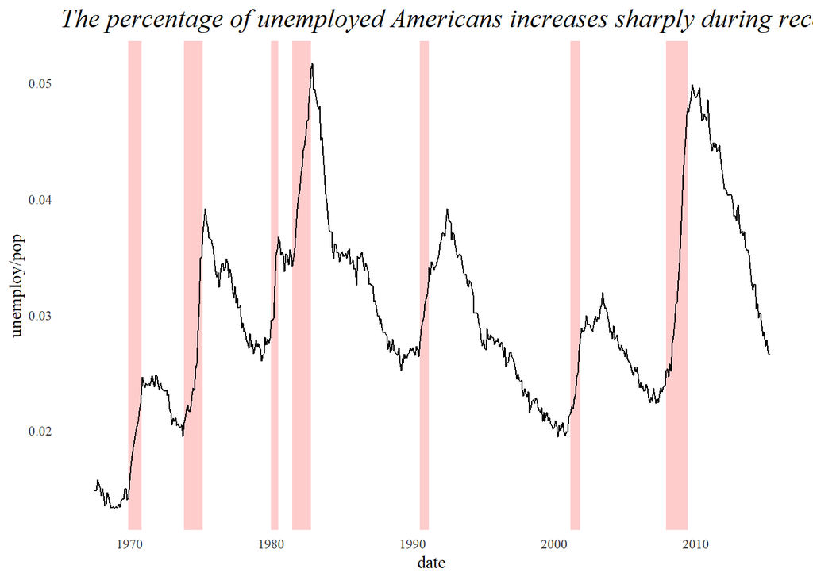

```r
plt_prop_unemployed_over_time
```

Set theme back to default:

```r
theme_set(theme_gray())
```